# First Delivery Statistics

Eduardo Alarcón & Alfonso Pineda

2022-12-03

# 1.Introduction:

The first delivery of the final project of Statistics of the degree of Computer Science. In this document, we (Alfonso Pineda and Eduardo Alarcón) will be showing the histogram of the main variable we have chosen for our project, is the $\textbf{energy}$ of a song, which is a value assigned by the spoify algorith to try and categorize songs and if they make people more or less energetic. As well, we will have a Box Plot and the statistical Measures on the same block as the histogram, the first one.

On the second block, we will show the $\textbf{rithm}$ of a song which we have tested to be the variable that has the most relation with the main variable. We are also going to show a Histogram, a Box Plot and the Statistical Measurements.

# 1st Block:

Including the data from the excel: The first thing we need to do is import the data we are going to work with.

```r
library(readxl)
SpotifySongs <- read_excel("songstats.xlsx")
#View(SpotifySongs)
```

### Histogram Then, we need to create the histogram, using R

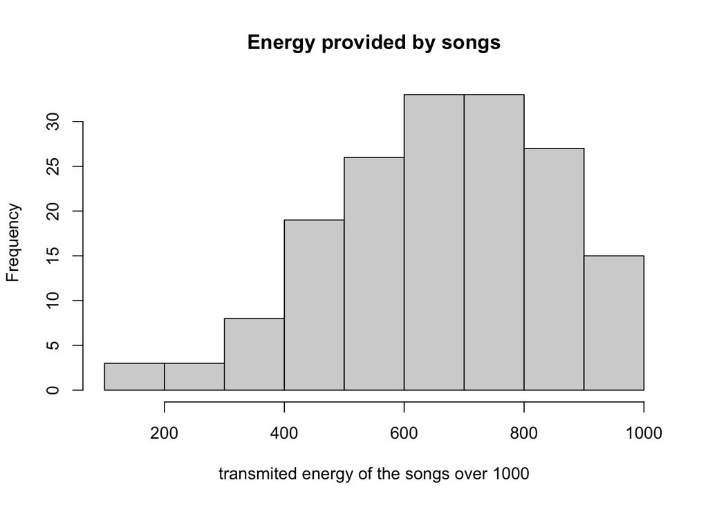

```r
SpotifySongs <- read_excel("songstats.xlsx")
energy <- SpotifySongs$energy
hist(energy, xlab = "transmited energy of the songs over 1000",
     main = "Energy provided by songs")
```

We have also created the histogram differentiating if the artist is a Male, Female, Band or Collaboration between different artists (we used different colors to view them):

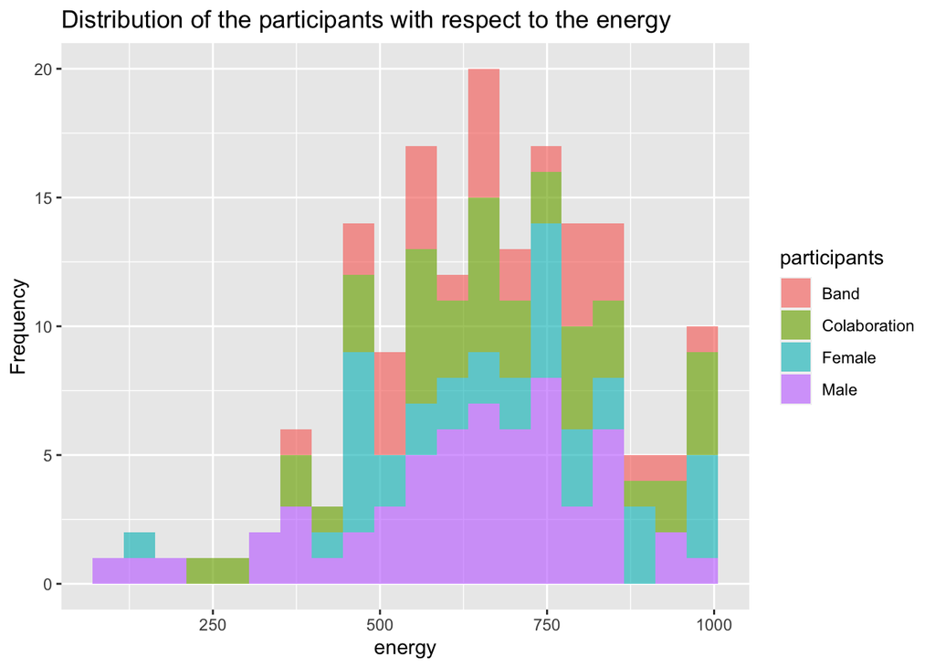

```r
# {r, fig.height = 4, fig.width = 6}

suppressWarnings(library(ggplot2))
SpotifySongs$participants <- "Male"
SpotifySongs$participants[SpotifySongs$GenderGroup == "F"] <- "Female"
SpotifySongs$participants[SpotifySongs$GenderGroup == "Band"] <- "Band"
SpotifySongs$participants[SpotifySongs$GenderGroup == "Colab"] <- "Colaboration"

qplot(energy, data=SpotifySongs, geom=c("histogram"), fill=participants,
      alpha=I(.65), main="Distribution of the participants with respect to the energy",
      xlab="energy", ylab="Frequency", bins=20)
```

```r
# Use bins=num to set the number of intervals
```

### Boxplot

Then, we also need to create a Box Plot:

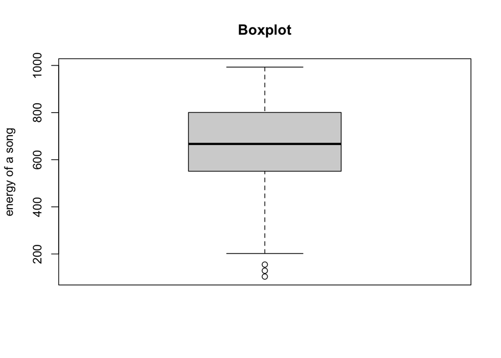

```r
#{r, fig.height = 4, fig.width = 5}
boxplot(energy, ylab = "energy of a song",
        main = "Boxplot")
```

### Statistical Measures

Now, it’s time for us to calculate the statistical measures of the main variable, $\textbf{energy}$ These measures are: the $\underline{mean}$, the $\underline{median}$, the $\underline{mode}$, the $\underline{percentiles}$, the $\underline{range}$, the $\underline{variance}$, and the $\underline{standard deviation}$.

First, we need to store the variable as Data in R, then, we ask R to describe the variable, which outputs the measures we need, as well as the number of elements there are, in this case N: 167

```r
energy<-SpotifySongs$energy
suppressWarnings(library(summarytools))
# Describe the variable energy
descr(energy)
```

```
## Descriptive Statistics
## energy
## N: 167
##
##                     energy
## ----------------- --------
##              Mean   660.92
##           Std.Dev   185.68
##               Min   104.00
##                Q1   551.00
##            Median   667.00
##                Q3   804.00
##               Max   993.00
##               MAD   188.29
##               IQR   249.50
##                CV     0.28
##          Skewness    -0.44
##       SE.Skewness     0.19
##          Kurtosis     0.07
##           N.Valid   167.00
##         Pct.Valid   100.00
```